# ph1861_hw2_ygu5

Yue Gu

2023-11-21

#Meta-Analysis Problem #1 (50 points) The following paper reviewed and meta-analyzed the proportion of Campylobacter cases that develop chronic sequelae, based on studies published prior to July 2011. (Keithlin 2014, “Systematic review and meta-analysis of the proportion of Campylobacter cases that develop chronic sequelae”). Import the number of cases that developed reactive arthritis (ReA) from page 7 of the article and follow the steps below to conduct a meta-analysis of the proportion/prevalence.

Please input data in the exact order from the paper. Calculate the proportion of people with Campylobacter who developed a ReA for each study. Add a count of 0.5 both to those reporting ReA outcome of 0% and to those totals. Calculate the logit of the outcome and logit of the standard error using the equation from Lipsey & Wilson. [Eq 3.5, p40].

```r
# read data
keith_data = read.csv("./data/Keithlin2014_ReA.csv") %>%
  janitor::clean_names() %>%
  mutate(prop_seq = round(number_developing_sequelae/number_of_people_with_campylobacter,4)) %>%
  mutate(number_of_people_with_campylobacter_add = ifelse(prop_seq==0.0000, number_of_people_with_campylobacter+0.5, number_of_people_with_campylobacter),
         number_developing_sequelae_add = ifelse(prop_seq==0.0000, number_developing_sequelae+0.5, number_developing_sequelae)) %>%
  mutate(prop_seq_add = number_developing_sequelae_add/number_of_people_with_campylobacter_add,
         logit_outcome = log(prop_seq/(1-prop_seq)),
         se_outcome = sqrt(1/(number_of_people_with_campylobacter_add*prop_seq_add)+1/(number_of_people_with_campylobacter_add*(1-prop_seq_add))))

# check total number of cases
s1=sum(keith_data$number_developing_sequelae_add)
# check total number
s2=sum(keith_data$number_of_people_with_campylobacter_add)
# check the proportion developing ReA
p1 = s1/s2
```

Now that the data are set, answer following questions with corresponding STATA or R code:  
(a) List the number of cases, total number, the proportion developing ReA, the logit outcome, and the logit standard error for the K=25 studies.

```r
# the logit outcome for the K=25 studies
knitr::kable(keith_data %>% select(first_author_year_reference_number, logit_outcome))
```

| first_author_year_reference_number | logit_outcome |
| --- | --- |
| Ternhag, [52] | -8.111428 |
| Schoenberg-Norio, jejuni [51] | -3.183275 |
| Townes, [47] | -4.269191 |
| Kosunen, [39] | -3.731341 |
| Petersen, [27] | -Inf |
| Short, [25] | -Inf |
| Hannu, [43] | -2.528269 |
| Hannu, [43] | -2.371141 |
| Hannu, [43] | -2.599044 |
| Hannu, [43] | -1.891268 |
| Hannu, [43] | -Inf |
| Melby, [32] | -5.060886 |
| Pitkanen, [23] | -2.871116 |
| Locht, [37] | -1.687537 |
| Schiellerup, [41] | -1.895664 |
| Hannu, [54] | -3.635228 |
| Pitkanen, [29] | -2.989555 |
| Helms, [38] | -6.724233 |
| Ponka, [40] | -3.832326 |
| Doorduyn, [44] | -3.029746 |
| Eastmond, [35] | -4.462676 |
| Eastmond [35] | -Inf |
| Melby, [55] | -3.623315 |
| Gumpel, [49] | -1.139566 |
| Bremell, [33] | -4.171143 |

```r
# the standard error for the K=25 studies
knitr::kable(keith_data %>% select(first_author_year_reference_number, se_outcome))
```

| first_author_year_reference_number | se_outcome |
| --- | --- |
| Ternhag, [52] | 0.2582326 |
| Schoenberg-Norio, jejuni [51] | 0.3608065 |
| Townes, [47] | 0.1752951 |
| Kosunen, [39] | 0.3577625 |
| Petersen, [27] | 1.4228107 |
| Short, [25] | 1.4375906 |
| Hannu, [43] | 0.1549041 |
| Hannu, [43] | 0.1450038 |
| Hannu, [43] | 0.1703968 |
| Hannu, [43] | 0.3792993 |
| Hannu, [43] | 1.4411534 |
| Melby, [32] | 1.0031596 |
| Pitkanen, [23] | 0.5934655 |
| Locht, [37] | 0.2094907 |
| Schiellerup, [41] | 0.0937037 |
| Hannu, [54] | 0.3377035 |
| Pitkanen, [29] | 0.3416105 |
| Helms, [38] | 0.2133312 |
| Ponka, [40] | 0.4126461 |
| Doorduyn, [44] | 0.2289442 |
| Eastmond, [35] | 1.0057307 |
| Eastmond [35] | 1.4226066 |
| Melby, [55] | 0.7164728 |
| Gumpel, [49] | 0.4062019 |
| Bremell, [33] | 1.0076629 |

The number of cases for the K=25 studies is 448, total number is 8.318^{4}, the proportion developing ReA is 0.0053859, the logit outcome and standard error for each studies could be found above  
(b) Run a fixed effects meta-analysis using the exponential form (ie, exponentiating the result back to the original scale). Attach the forest plot.

```r
# run fixed effects meta-analysis for a single proportion
library(meta)
m.bin <- metaprop(number_developing_sequelae_add,number_of_people_with_campylobacter_add,
                 data = keith_data,
                 studlab = paste(first_author_year_reference_number),
                 comb.fixed = T, comb.random = T,
                 method = 'GLMM',sm = "PLOGIT",
                 model.glmm = "UM.FS")
m.bin
```

```
## Number of studies: k = 25
## Number of observations: o = 83180
## Number of events: e = 448
##
##                      proportion           95%-CI
## Common effect model      0.0054 [0.0049; 0.0059]
## Random effects model     0.0254 [0.0132; 0.0482]
##
## Quantifying heterogeneity:
##  tau^2 = 2.4692; tau = 1.5714; I^2 = 97.7% [97.2%; 98.1%]; H = 6.55 [5.96; 7.21]
##
## Test of heterogeneity:
##             Q d.f.  p-value
##  Wald 1030.79   24 < 0.0001
##  LRT  2033.29   24        0
##
## Details on meta-analytical method:
## - Random intercept logistic regression model
## - Maximum-likelihood estimator for tau^2
## - Logit transformation
```

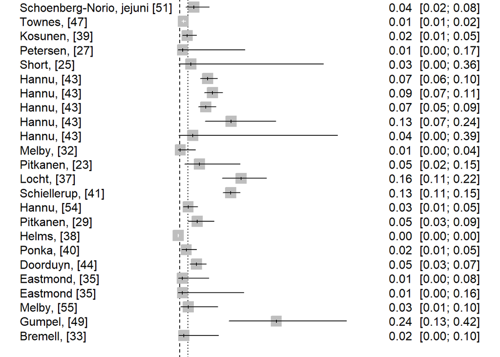

```r
# forest plot
forest(m.bin, leftcols = c('studlab'), overall = T, weight.study="random",hetstat = T, overall.hetstat = T)
```

The results from fixed effects meta-analysis and forest plot are shown above.  
(c) What is the pooled estimate? Is it significant? Please interpret the result.  
The pooled estimate for Heterogeniety across all the studies is 0.01 for common-effects model and 0.03 for random effects model and $I^2=0.98, \tau^2=2.4692$ with p<0.01, we interpret it as 98% of the variation across the studies is due to heterogeneity rather than chance and 2.4692 is the amount of heterogeneity between the study effect esimates; with significant p-value, we conclude that there is significant heterogeneity between the 25 studies, and further random effect meta-analysis is needed.  
(d) If necessary, run a random effect meta-analysis using exponential form.

```r
# random effect meta-analysis (same command in R)
m.bin <- metaprop(number_developing_sequelae_add,number_of_people_with_campylobacter_add,
                 data = keith_data,
                 studlab = paste(first_author_year_reference_number),
                 comb.fixed = T, comb.random = T,
                 method = 'GLMM',sm = "PLOGIT",
                 model.glmm = "UM.FS")
m.bin
```

```
## Number of studies: k = 25
## Number of observations: o = 83180
## Number of events: e = 448
##
##                      proportion           95%-CI
## Common effect model      0.0054 [0.0049; 0.0059]
## Random effects model     0.0254 [0.0132; 0.0482]
##
## Quantifying heterogeneity:
##  tau^2 = 2.4692; tau = 1.5714; I^2 = 97.7% [97.2%; 98.1%]; H = 6.55 [5.96; 7.21]
##
## Test of heterogeneity:
##             Q d.f.  p-value
##  Wald 1030.79   24 < 0.0001
##  LRT  2033.29   24        0
##
## Details on meta-analytical method:
## - Random intercept logistic regression model
## - Maximum-likelihood estimator for tau^2
## - Logit transformation
```

#Meta-Analysis Problem #2 (50 points) We conducted a systematic review (SR) of second generation antidepressants that compared fluoxetine to any other anti-depressant. Although this SR resulted in an extensive network of multiple treatment comparisons, for this assignment, we will treat this review as “pairwise.” Thus we will assume all comparator arms to fluoxetine are called “other active treatment.” The Excel file is attached above. The outcome is “efficacy” and the number experiencing efficacy and total number are given. If a study has 3 treatments, you will only compare fluoxetine with the first treatment given in that study. (a) Conduct an appropriate pairwise meta-analysis of these RCT data. Present the forest plot and pooled effect size.

```r
# read data
fluo_data = readxl::read_xlsx("./data/HW2 Fluoxetine RCT Data -1.xlsx",sheet = 1) %>%
  janitor::clean_names()
# reshape the data into binary
fluo_data_wide = fluo_data %>%
  mutate(study_id = ifelse(is.na(study_id), lag(study_id), study_id)) %>%
  filter(study_id!="") %>%
  group_by(study_id) %>%
  mutate(row = row_number(),
         trt = if_else(treatment=="fluoxetine", "fluoxetine", "others")) %>%
  ungroup() %>%
  pivot_wider(names_from = trt, values_from = c(number_efficacy,total_n), names_sep = "_") %>%
  select(-row,-treatment,-weeks_followup,-outcome_scale) %>%
  mutate(number_efficacy_others = as.numeric(number_efficacy_others),
         number_efficacy_fluoxetine = as.numeric(number_efficacy_fluoxetine)) %>%
  group_by(study_id) %>%
  summarise(across(everything(), ~ if(all(is.na(.))) NA else sum(., na.rm = T)))
# keep only the trt and control data
fluo_data_wide$flu_e1=fluo_data_wide$number_efficacy_fluoxetine
fluo_data_wide$flu_e0=fluo_data_wide$total_n_fluoxetine - fluo_data_wide$number_efficacy_fluoxetine
fluo_data_wide$others_e1=fluo_data_wide$number_efficacy_others
fluo_data_wide$others_e0=fluo_data_wide$total_n_others - fluo_data_wide$number_efficacy_others
fluo_data_wide[is.na(fluo_data_wide)]=.5
# check data
new_list = fluo_data_wide[,c("study_id", "flu_e0", "flu_e1", "others_e0", "others_e1")]
new_list
```

```
## # A tibble: 53 × 5
##    study_id      flu_e0 flu_e1 others_e0 others_e1
##    <chr>          <dbl>  <dbl>     <dbl>     <dbl>
##  1 2906/421         0.5    0.5       0.5       0.5
##  2 29060/365       38     32        35        33
##  3 Aguglia1993     30     26        17        35
##  4 Alves1999       12     35         4        36
##  5 Amini2005       10      8         6        12
##  6 Annseau1994     50     43        65        32
##  7 Bennie1995      81     63        69        73
##  8 Bosc1997a       72     55        77        49
##  9 Bosc1997b       38     51        33        46
## 10 Bougerol1997a   71    113        58       115
## # ℹ 43 more rows
```

```r
# conduct pairwise meta-analysis
m.bin <- metabin(others_e1, total_n_others, flu_e1, total_n_fluoxetine,
                 data = fluo_data_wide,
                 studlab = paste(study_id),
                 comb.fixed = T,comb.random = T,
                 method = 'mh',sm = "OR",
                 model.glmm = "UM.FS")
m.bin
```

```
## Number of studies: k = 53
## Number of observations: o = 10386
## Number of events: e = 5526
##
##                          OR           95%-CI    z p-value
## Common effect model  1.1047 [1.0179; 1.1989] 2.38  0.0171
## Random effects model 1.1350 [1.0275; 1.2537] 2.50  0.0126
##
## Quantifying heterogeneity:
##  tau^2 = 0.0305 [0.0000; 0.1011]; tau = 0.1747 [0.0000; 0.3180]
##  I^2 = 23.3% [0.0%; 45.8%]; H = 1.14 [1.00; 1.36]
##
## Test of heterogeneity:
##      Q d.f. p-value
##  67.81   52  0.0694
##
## Details on meta-analytical method:
## - Mantel-Haenszel method
## - Inverse variance method
## - Restricted maximum-likelihood estimator for tau^2
## - Q-Profile method for confidence interval of tau^2 and tau
```

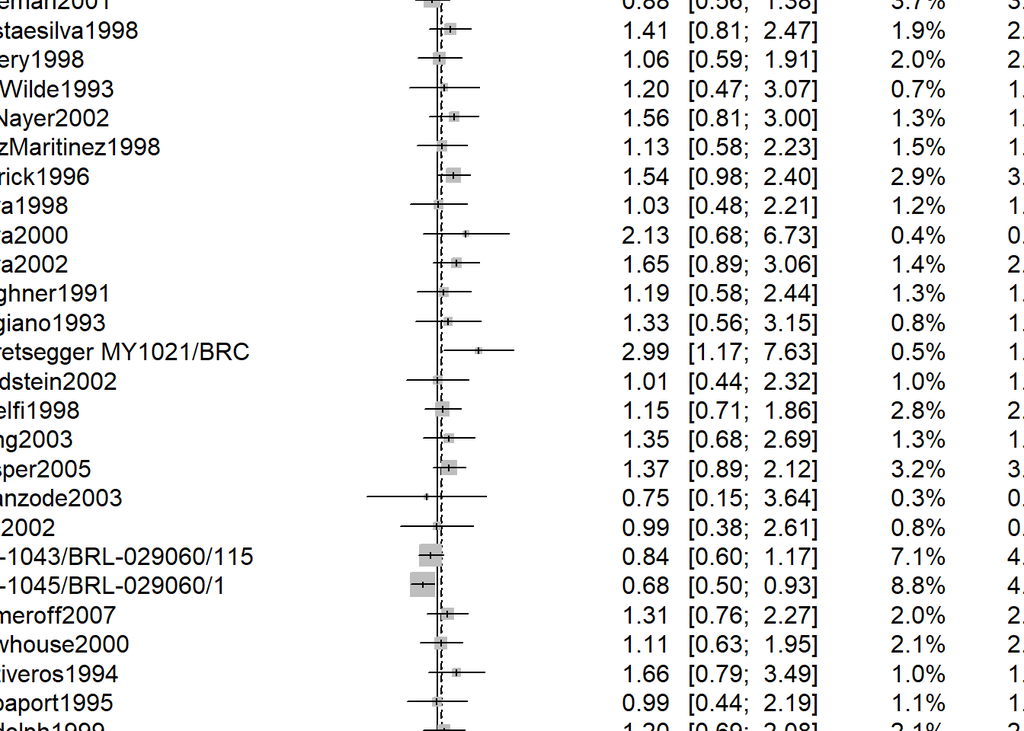

```r
# forest plot
forest(m.bin, leftcols = c('studlab'), cex=0.5)
```

2. Does there appear to be publication bias? Please justify in 2 sentences or less.
3. Is a random or fixed effects model more appropriate here? Justify in 2 sentences or less.
4. Write a very short Methods and a Results paragraph summarizing your findings from (a-c).
5. Would you consider any subgroup or sensitivity analysis for this meta-analysis? Explain which one(s) and justify your answer.